# SBWD ITS processing

Emily Smenderovac, edited by Maddie McCaig

2023-11-24

- Leaf samples broken down, homogenized, and frozen at GLFC
- DNA extracted using the Qiagen PowerSoil Kit
- DNA sequenced via metabarcoding via the GRDI ecobiomics project (16S, ITS)
- Sequence data processed using the MetaWorks pipeline version 1.10.0 (Porter, T.M., Hajibabaei, M. 2020. METAWORKS: A flexible, scalable bioinformatic pipeline for multi-marker biodiversity assessments. BioRxiv, doi: https://doi.org/10.1101/2020.07.14.202960)
- Processed sequence data with samples containing <1000 seq removed
- Sequence data was not rarefied as read counts reached a plateau
- Raw data (after bioinformatic processing no rarefaction) can be found in file ending with results.csv.

Bioinformatics run steps: 1- transfer raw seq files to data file 2- cp pipeline files to live.run 3- cd to live.run folder 4- create/activate conda environment 5- rename raw seq files as need to match config_ESV file 6- edit config_ESV file 7- run using snakemake 8- move results files to archive 9- run CM.processing.R code to generate run stats and rarefied community matrix 10- rm raw seq data

*See https://github.com/terrimporter/MetaWorks for specific details on metaworksv1.10.0 pipeline

Version notes: Conda v4.9.1 RDP 2.13 Fungal_Unitev8.3 - make sure to cite Terri on this as well because RDP classifier didn’t have it updated with 2021 version https://github.com/terrimporter/UNITE_ITSClassifier

Primer information: 1. ITS2 * Forward “fITS9” (Ihrmark et al., 2012): sequence = GAACGCAGCRAAIIGYGA, Cutadapt = GAACGCAGCRAADDGYGA * Reverse “ITS4” (White et al., 1990): sequence = TCCTCCGCTTATTGATATGC, Cutadapt = GCATATCAATAAGCGGAGGA **Cutadapt = I->D, rev com reverse primer

## Copied fastq’s to Linux directory and renamed

```bash
## Set up directories for processing
#create the bioinformatics folder that this is being saved in
mkdir Bioinformatics
cd Bioinformatics
mkdir current.pipelines
mkdir live.run
mkdir current.reference.sets

#Latest MetaWorks pipeline
wget -P /home/mmccaig/Bioinformatics/current.pipelines https://github.com/terrimporter/MetaWorks/releases/download/v1.10.0/MetaWorks1.10.0.zip
unzip /home/mmccaig/Bioinformatics/current.pipelines/MetaWorks1.10.0.zip
#Download RDP classifier if haven't already

wget -P /home/mmccaig/Bioinformatics/live.run https://sourceforge.net/projects/rdp-classifier/files/rdp-classifier/rdp_classifier_2.13.zip/download

https://sourceforge.net/projects/rdp-classifier/files/latest/download

#don't need to unzip rdp classifier?
#Download 2021 ITS Unite (RDP Classifier has it included but only the 2014, it hasn't been updated with the latest version)
#Get the latest RDP-formatted UNITE training set
wget -P /home/mmccaig/Bioinformatics/live.run https://github.com/terrimporter/UNITE_ITSClassifier/releases/download/v2.0/mydata_trained.tar.gz
# decompress it
tar -xzf mydata_trained.tar.gz
#ORFfinder
#this is only needed for pseudogene filtering which is not necessary for 16s and ITS so skip this step
#wget ftp://ftp.ncbi.nlm.nih.gov/genomes/TOOLS/ORFfinder/linux-i64/ORFfinder.gz
#gunzip ORFfinder.gz
#not sure what chmod 755 does?? something about user permissions
#chmod 755 ORFfinder
#mv ORFfinder ~/miniconda3/envs/MetaWorks_v1.10.0/bin/.

#probably need to install miniconda too
wget -P /home/mmccaig
https://repo.anaconda.com/miniconda/Miniconda3-py39_4.12.0-Linux-x86_64.sh
bash ~/miniconda3/miniconda.sh -b -u -p ~/miniconda3
rm -rf ~/miniconda3/miniconda.sh
~/miniconda3/bin/conda init bash
~/miniconda3/bin/conda init zsh

#for some reason when I unzipped the MetaWorks file it ended up in Bioinformatics folder rather than current pipelines but that's fine
#copy it to live.run folder
cd Bioinformatics
cp -r MetaWorks1.10.0/* live.run

### Used live.run because any attempts to use alternative paths failed horribly.
cd live.run

#remember that this directory needs to be within the folder you are running in
#so if have live.run/MetaWorks1.10.0 then it needs to be in there
#but if just have live.run and the stuff from the MetaWorks1.10.0 folder copied into live.run, the ITS_fastq can be in there.
#basically just have to have everything in the same folder as the MetaWorks stuff or it will cause issues
mkdir ITS_fastq

## copy over files
#copied over using WinSCP
cp ../../../EnvChem/project_data_Emilson/SBWD/leafpack_microbes/*ITS_fastq_files/* ITS_fastq

scp Y:\project_data_Emilson\SBWD\leafpack_microbes\*ITS_fastq_files* ITS_fastq mmccaig@132.156.202.0:\Bioinformatics\live.run\ITS_fastq

## fix file names for parsing

cd ITS_fastq
#\. This means to actually look for the . Character
#saying to rename anything that is .fq to .fastq because metaworks doesn't like the .fq

rename  \.fq \.fastq  *
#also getting rid of all the extra stuff in the file names
for f in *; do mv "$f" "${f//_ITS_*_R/_R}"; done
for f in *; do mv "$f" "${f//GRDI-ECO_*_AM-EE-/}"; done

#change old site names to new site names
for f in *; do mv "$f" "${f//N1/L09}"; done
for f in *; do mv "$f" "${f//N2/L11}"; done
for f in *; do mv "$f" "${f//N4/C04}"; done
for f in *; do mv "$f" "${f//N5/C05}"; done
for f in *; do mv "$f" "${f//N6/C07}"; done
for f in *; do mv "$f" "${f//S1/L10}"; done
for f in *; do mv "$f" "${f//S2/L12}"; done
for f in *; do mv "$f" "${f//S3/L08}"; done
for f in *; do mv "$f" "${f//S4/U01}"; done
for f in *; do mv "$f" "${f//S5/U02}"; done
for f in *; do mv "$f" "${f//S6/U03}"; done
for f in *; do mv "$f" "${f//P20/C06}"; done

#if you haven't set up the environment yet you need to do this
#need to do this from within the MetaWorks folder
conda env create -f environment.yml
#but only do it once, now should be good to go

#note some conda issues creeping up after the Linux machine was updated
#need to run exec bash then:
#export CURL_CA_BUNDLE=/etc/pki/ca-trust/extracted/openssl/ca-bundle.trust.crt
#export REQUESTS_CA_BUNDLE=/etc/pki/ca-trust/extracted/openssl/ca-bundle.trust.crt
#export SSL_CERT_FILE=/etc/pki/ca-trust/extracted/openssl/ca-bundle.trust.crt

cd ..

conda activate MetaWorks_v1.10.0

## config file was edited at this point - if necessary ### standard ITS config file is MetaWorks1.8.1 folder
#may need to increase memory significantly for rdp classifier. default is 8, try 30 or 50
#also need to be careful with path names as MetaWorks can get confused. if you have live.run/MetaWorks, need to run it from right in MetaWorks
#for path to rdp classifier it should be /home/mmccaig/Bioinformatics/live.run etc. can't have it as ~/Bioinformatics

#Run script after editing config.yaml file
snakemake --jobs 36 --snakefile snakefile_ESV --configfile config_ESV_ITS.yaml

cp config_ESV_ITS.yaml ITS
cp ITS_adapters.fasta ITS

rm -r ITS_fastq
mv ITS ../../SBWD_ITS_20221026
```

```bash
## get files over to appropriate folder
#I just used WinSCP to transfer back to ENVCHEM

#Emily did this way
#mkdir EnvChem/wet_analyses_bioinformatics_archive/SBWD/ITS/*

#scp -r esmender@132.156.202.255:Bioinformatics/SBWD_ITS_20210817 E:/wet_analyses_bioinformatics_archive/SBWD
```

## QAQC of Metabarcoding Data

```r
library(dplyr)
library(vegan)
library(readr)
library(tidyverse)
PROJ.ID <- "SBWD"
amplicon <- "ITS"

drive <- "//NRONP6AwvFSP001/EnvChem"

## pull the processing that has been done most recently
archives <- list.dirs(paste(drive, "wet_analyses_bioinformatics_archive", PROJ.ID, sep="/"), recursive = FALSE)

archives <- grep(amplicon, archives, value = TRUE)
archives_date <- as.POSIXct(str_extract(archives, "[[:digit:]]+$"), format = "%Y%m%d")
archive <- archives[archives_date == max(archives_date)]

rm(archives, archives_date)
```

## Summary of Sequence counts before and after primer trimming

```r
## Import data
summary.table.1 <- data.frame()
for(stat in c("R1", "R2", "paired", "trimmed")){
  temp <-  as.data.frame(read.delim(paste(archive, "stats", paste0(stat, ".stats"), sep = "/"), header = TRUE))
  temp.sum <- as.data.frame(as.list(c(sum(temp$TotSeqs),mean(temp$TotSeqs), mean(temp$MinLength), mean(temp$MaxLength), mean(temp$MeanLength))),col.names=c("Total seq number (across samples)","Mean seq number (per sample)", "min seq length","max seq length","mean seq length"), check.names = FALSE)
  summary.table.1 <- rbind(summary.table.1, temp.sum)
  assign(stat, temp)
  rm(temp, temp.sum)
}
rownames(summary.table.1) <- c("R1", "R2", "paired", "trimmed")

## export summary table
write.csv(summary.table.1,file=paste0(archive,"/SummaryStats_",PROJ.ID,"_",Sys.Date(),"_",amplicon,".csv"))

knitr::kable(summary.table.1)
```

|  | Total seq number (across samples) | Mean seq number (per sample) | min seq length | max seq length | mean seq length |
| --- | --- | --- | --- | --- | --- |
| R1 | 22907324 | 79816.46 | 106.13240 | 263.2927 | 262.3768 |
| R2 | 22907324 | 79816.46 | 106.04878 | 263.2927 | 262.4487 |
| paired | 18256016 | 63609.81 | 60.67944 | 475.9408 | 334.5734 |
| trimmed | 18161691 | 63281.15 | 164.03136 | 443.6794 | 296.3594 |

## Summary of dereplication and chimera removal

```r
dereplication <- read.csv(paste(archive,  "dereplication.log", sep = "/"), header = FALSE)
dereplication<-as.list(c(as.character(dereplication$V1[5]),as.character(dereplication$V2[4]), as.character(dereplication$V3[4]), as.character(dereplication$V4[4])))
dereplication[1]<-gsub(" unique sequences", "", dereplication[1])
dereplication[2]<-gsub(" min ", "", dereplication[2])
dereplication[3]<-gsub(" max ", "", dereplication[3])
dereplication[4]<-gsub(" avg ", "", dereplication[4])

chimeraRemoval <- read.csv(paste(archive, "chimeraRemoval.log", sep = "/"), header=FALSE)
chimeraRemoval<-as.list(c(as.character(chimeraRemoval$V1[12]),as.character(chimeraRemoval$V2[4]), as.character(chimeraRemoval$V3[4]), as.character(chimeraRemoval$V4[4])))
chimeraRemoval[1]<-gsub("F230/cat.denoised: 66/9694 chimeras ", "", chimeraRemoval[1])
chimeraRemoval[2]<-gsub(" min ", "", chimeraRemoval[2])
chimeraRemoval[3]<-gsub(" max ", "", chimeraRemoval[3])
chimeraRemoval[4]<-gsub(" avg ", "", chimeraRemoval[4])

dereplication <- as.data.frame(dereplication, col.names=c("number","min", "max", "mean"))
chimeraRemoval <- as.data.frame(chimeraRemoval, col.names=c("number","min", "max", "mean"))
summary_table2 <- rbind(dereplication, chimeraRemoval)
row.names(summary_table2) <- c("dereplication", "chimera removal")
knitr::kable(summary_table2)
```

|  | number | min | max | mean |
| --- | --- | --- | --- | --- |
| dereplication | 2991701 | 150 | 474 | 297 |
| chimera removal | ITS/cat.denoised: 1161/12155 chimeras (9.6%) | 151 | 456 | 312 |

## Community Matrix and Rarefaction Curves

```r
tax <- read.csv(paste(archive, "results.csv", sep="/"))
nrow.orig <- nrow(tax)

tax.check <- tax[!complete.cases(tax), ]

#which non-Fungi kingdoms were picked up?
unique(tax[c("Kingdom")])
```

```
##                               Kingdom
## 1     k__Eukaryota_kgd_Incertae_sedis
## 5                            k__Fungi
## 55                   k__Viridiplantae
## 174                      k__Alveolata
## 492                       k__Rhizaria
## 1777                       k__Metazoa
## 5969                  k__Stramenopila
## 19994                   k__Nucleariae
## 44870                     k__Protista
## 53441            k__Choanoflagellozoa
## 64017                 k__Rhodoplantae
## 74719                   k__Euglenozoa
## 85025                    k__Amoebozoa
```

```r
## remove rows that aren't Fungi
tax <- tax[grep("Fungi", tax$Kingdom), ]

print(paste0("Number of ASVs removed based on ID as not Fungi: ", nrow.orig-nrow(tax)))
```

```
## [1] "Number of ASVs removed based on ID as not Fungi: 27929"
```

```r
## Remove amplicon from ESV names and rename as GlobalESV

tax[,1] <- sub(paste0(amplicon, "\\_"), "", tax[,1])
colnames(tax)[1] <- "GlobalESV"
```

```r
ESV <- tax %>%
  group_by(SampleName) %>%
  # filter out any samples less than 1000 reads ## also removes any taxa that would now be = 0
  filter(sum(ESVsize) > 1000) %>%
  pivot_wider(names_from = SampleName, values_from = ESVsize, values_fn = sum, values_fill = 0) %>%
  column_to_rownames("GlobalESV")

print(paste0(str_c(unique(tax$SampleName)[!unique(tax$SampleName) %in% colnames(ESV)], collapse = ", "), " removed due to low read count (<1000)."))
```

```
## [1] "GRDI_L08_2_20200921_ITS_S013D27_ITSM01549, UQAM_U02_1_20220901_ITS_ITSM03992, UQAM_U03_4_20220901_ITS_ITSM03992 removed due to low read count (<1000)."
```

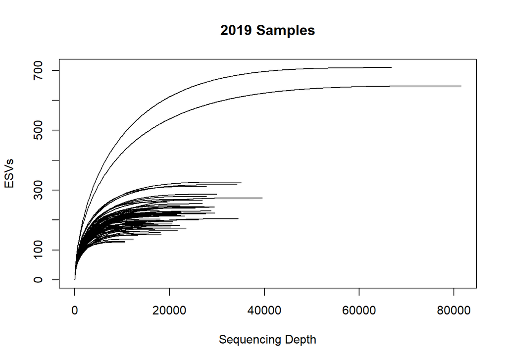

```r
rarecurve(t(ESV[,colnames(ESV) %in% grep("2019", tax$SampleName, value = T)]), step = 171, ylab="ESVs", xlab="Sequencing Depth", main = "2019 Samples", label = FALSE)
```

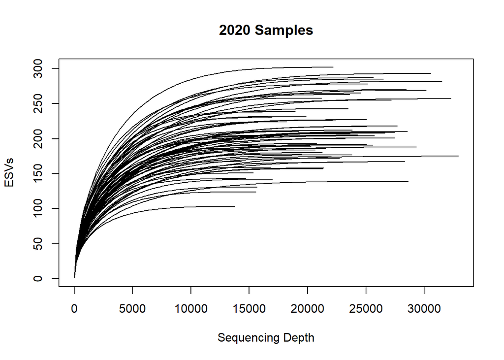

```r
rarecurve(t(ESV[,colnames(ESV) %in% grep("2020", tax$SampleName, value = T)]), step = 171, ylab="ESVs", xlab="Sequencing Depth", main = "2020 Samples", label = FALSE)
```

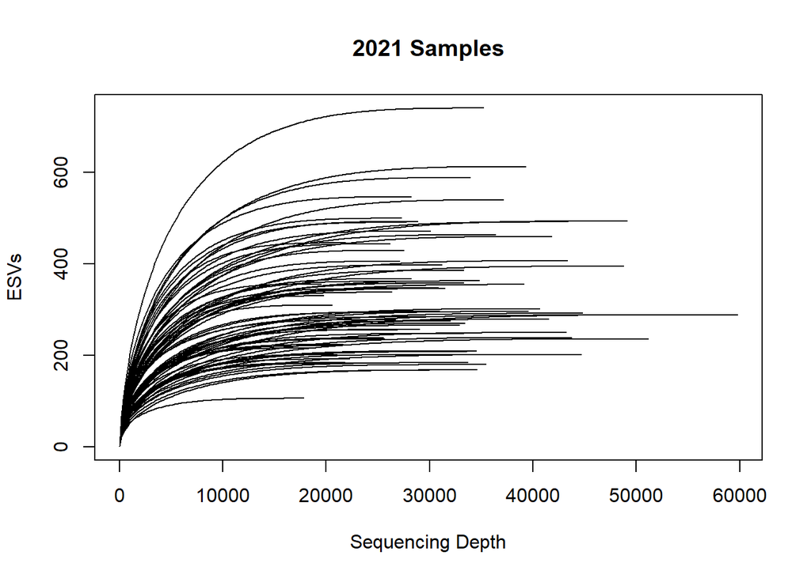

```r
rarecurve(t(ESV[,colnames(ESV) %in% grep("2021", tax$SampleName, value = T)]), step = 171, ylab="ESVs", xlab="Sequencing Depth", main = "2021 Samples", label = FALSE)
```

Data look to be reaching plateau, so rarefied data were not supplied for subsequent analyses.

```r
#clean up dataset and export
#remove strand column
ESV <- select(ESV, -"Strand")
#fix column names (want only C04_4_2019)
#for columns 26 to 239
names(ESV)[26:239] <- substr(names(ESV)[26:239],1,10)

datayears <- as.numeric(unique(str_sub(str_extract(tax$SampleName, "_[[:digit:]]{2,}_.+$"),2,5)))

## Write the cleaned ESV data to the appropriate project data folder
write.csv(ESV, paste(drive, "project_data_Emilson", PROJ.ID, "leafpack_microbes", paste0(PROJ.ID, "_",  min(datayears), "-", max(datayears), "_lp_", tolower(amplicon), ".csv"), sep="/"))
```

```r
## TURN TO eval = True if rarefying required. If all samples reach plateau, rarefying is not necessary for compositional analysis, relative abundance or presence/absence analysis.

ESV.4.r <- t(ESV[,colnames(ESV) %in% tax$SampleName])

## Rarefy based on the 15th percentile
ESV.r <- rrarefy(ESV.4.r, quantile(rowSums(ESV.4.r), .15))

## Remove any sites with 10X less the 15th percentile
ESV.r <- ESV.r[rowSums(ESV.r) > quantile((rowSums(ESV.4.r)), .15)/10, ]
## get rid of any ESVs that are now zero
ESV.r<-(ESV.r[,colSums(ESV.r) >0])

if(sum(!rownames(ESV.4.r) %in% rownames(ESV.r))>0){
  print(paste0(str_c(row.names(ESV.4.r)[!rownames(ESV.4.r) %in% rownames(ESV.r)], collapse = ", "), "removed as they were less than the 15th percentile"))
  }else{
  print("No samples removed in rarefaction")
}

## add taxa descriptions
ESV.r <- t(as.data.frame(ESV.r)) %>% as.data.frame()

tax4join <- unique(tax[,!colnames(tax) %in% c("SampleName", "ESVsize")])

ESV.r$GlobalESV <- rownames(ESV.r)

ESV.r <- ESV.r %>%
  left_join(tax4join, by="GlobalESV")


## Check Sequence depth before and after rarefaction
#Check sequence depth before and after rarefaction

depth.check<-as.data.frame(colSums(ESV[, colnames(ESV) %in% tax$SampleName]))
depth.check[,2]<-colSums(ESV.r[, colnames(ESV.r) %in% tax$SampleName])
colnames(depth.check)<-c("esv.seq", "esvr.seq")
depth.check$seq.discarded<-depth.check[,1]-depth.check[,2]
depth.check.summary<-as.data.frame(c(mean(depth.check[,"esv.seq"]),median(depth.check[,"esv.seq"]), sd(depth.check[,"esv.seq"]), min(depth.check[,"esv.seq"]), max(depth.check[,"esv.seq"])))
colnames(depth.check.summary)<-"esv.seq"
row.names(depth.check.summary)<-c("mean", "median","sd", "min", "max")
depth.check.summary$esvr.seq<-c(mean(depth.check[,"esvr.seq"]), median(depth.check[,"esvr.seq"]), sd(depth.check[,"esvr.seq"]), min(depth.check[,"esvr.seq"]), max(depth.check[,"esvr.seq"]))
knitr::kable(depth.check.summary)

write.csv(ESV.r, paste(drive, "project_data_Emilson", PROJ.ID, "leafpack_microbes", paste0(PROJ.ID, "_",  min(datayears), "-", max(datayears), "_lp_", tolower(amplicon), "_rarefied15.csv"), sep="/"))
```